# FigureYa188CNVload

小丫画图出品

2020-7-26

欢迎关注“小丫画图”公众号，回复“小白”，看小视频，实现点鼠标跑代码。

小丫微信: epigenomics E-mail: figureya@126.com

作者：SRF

小丫编辑校验

# 需求描述

比较不同分子分型之间的focal-level gain & loss burden 和 arm-level gain & loss burden，并且画出下图。

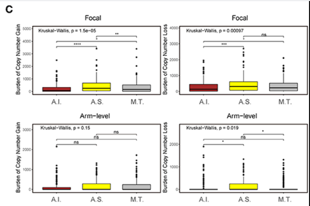

出自https://pubmed.ncbi.nlm.nih.gov/31998649/

FIGURE 4 | Genetic and copy number alterations across immune subtypes. (A,C) Distribution of TMB (A) and focal and broad copy number alterations (C) among the TME subtypes. The statistical significance of pairwise comparisons is annotated with symbols in which ns and *** represent not significant (P > 0.05) and P ≤ 0.001, respectively A.I., A.S., and M.T. represent the active immune, active stroma and mixed type, respectively.

# 应用场景

刻画分型背后的拷贝数burden变化，不同于TMB，copy number load机制更多的涉及到免疫逃逸方面。类似的文章应用还有[Identification of an Immune-specific Class of Hepatocellular Carcinoma, Based on Molecular Features](https://pubmed.ncbi.nlm.nih.gov/28624577/)

**相似结论请引用文章：** Shen R, Li P, Li B, Zhang B, Feng L, Cheng S. Identification of Distinct Immune Subtypes in Colorectal Cancer Based on the Stromal Compartment. Front Oncol. 2019;9:1497. doi:10.3389/fonc.2019.01497

# 环境设置

使用国内镜像安装包

```r
options("repos"= c(CRAN="https://mirrors.tuna.tsinghua.edu.cn/CRAN/"))
options(BioC_mirror="http://mirrors.tuna.tsinghua.edu.cn/bioconductor/")
```

加载包

```r
library(cowplot)
library(ggplot2)
library(ggpubr)
library(tidyverse)
Sys.setenv(LANGUAGE = "en") #显示英文报错信息
options(stringsAsFactors = FALSE) #禁止chr转成factor
```

# 输入文件

需要GISTIC的两个输出文件focal_data_by_genes.txt和broad_data_by_genes.txt，以及分组临床输入pdat.txt文件。

具体GISTIC运行输入文件的获取和运行操作参考FigureYa79CNV的附录部分，用的是GISTIC的默认参数。

```r
# 加载focal和broad data
focalload <- read.table("focal_data_by_genes.txt", header = T, sep = "\t", check.names = F)
rownames(focalload) <- focalload$Gene.Symbol
head(focalload)[, 1:8]
```

```
##   Gene Symbol Gene ID Cytoband TCGA-3L-AA1B-01A-11D-A36W-01
## 1       ACAP3  116983  1p36.33                            0
## 2      ACTRT2  140625  1p36.32                            0
## 3        AGRN  375790  1p36.33                            0
## 4     ANKRD65  441869  1p36.33                            0
## 5      ATAD3A   55210  1p36.33                            0
## 6      ATAD3B   83858  1p36.33                            0
##   TCGA-4N-A93T-01A-11D-A36W-01 TCGA-4T-AA8H-01A-11D-A40O-01
## 1                            0                            0
## 2                            0                            0
## 3                            0                            0
## 4                            0                            0
## 5                            0                            0
## 6                            0                            0
##   TCGA-5M-AAT4-01A-11D-A40O-01 TCGA-5M-AAT5-01A-21D-A40O-01
## 1                            0                       -0.819
## 2                            0                       -0.819
## 3                            0                       -0.819
## 4                            0                       -0.819
## 5                            0                       -0.819
## 6                            0                       -0.819
```

```r
broadload <- read.table("broad_data_by_genes.txt", header = T, sep = "\t", check.names = F)
rownames(broadload) <- broadload$Gene.Symbol

# 加载分组信息
crcpdata  <- read.table("pdat.txt", header = T, sep = "\t")
head(crcpdata)
```

```
##           Tumor.sample.barcode   TME_Subtype         sampleID
## 1 TCGA-4N-A93T-01A-11R-A37K-07 Active immune TCGA-4N-A93T-01A
## 2 TCGA-4T-AA8H-01A-11R-A41B-07 Active immune TCGA-4T-AA8H-01A
## 3 TCGA-A6-2672-01A-01R-0826-07 Active immune TCGA-A6-2672-01A
## 4 TCGA-A6-2676-01A-01R-0826-07 Active immune TCGA-A6-2676-01A
## 5 TCGA-A6-2679-01A-02R-1410-07 Active immune TCGA-A6-2679-01A
## 6 TCGA-A6-2686-01A-01R-A32Z-07 Active immune TCGA-A6-2686-01A
```

# 分别统计focal和broad的gain load和loss load

```r
## focal
focalload <- focalload[, -c(1:3)]
focalgainload <- focalload
focallossload <- focalload
# gain
focalgainload[focalgainload > 0]  <- 1
focalgainload[focalgainload < 0]  <- 0
focalgainload <- data.frame(colSums(focalgainload))
colnames(focalgainload) <- "focal_gain_load"
# loss
focallossload[focallossload > 0]  <- 0
focallossload[focallossload < 0]  <- 1
focallossload <- data.frame(colSums(focallossload))
colnames(focallossload) <- "focal_loss_load"

## broad
broadload <- broadload[, -c(1:3)]
broadload_gain <- broadload
broadload_loss <- broadload
# gain
broadload_gain[broadload_gain > 0] <- 1
broadload_gain[broadload_gain < 0] <- 0
broadload_gain <- data.frame(colSums(broadload_gain))
colnames(broadload_gain) <- "broad_gain_load"
# loss
broadload_loss[broadload_loss > 0] <- 0
broadload_loss[broadload_loss < 0] <- 1
broadload_loss <- data.frame(colSums(broadload_loss))
colnames(broadload_loss) <- "broad_loss_load"

## 把focal和broad的gain load和loss load这四列merge在一起
copyloadlist <- list(focalgainload = focalgainload, focallossload = focallossload,
                     broadload_gain = broadload_gain, broadload_loss = broadload_loss)
for (i in 1:length(copyloadlist)){
  tmpdata <- copyloadlist[[i]]
  copyloadlist[[i]] <- data.frame(barcode = rownames(tmpdata), tmpdata)
}
copyload <- Reduce(function(x, y) merge(x = x, y = y, by = "barcode"),
                   copyloadlist)
head(copyload)
```

```
##                        barcode focal_gain_load focal_loss_load broad_gain_load
## 1 TCGA-3L-AA1B-01A-11D-A36W-01               0             125               0
## 2 TCGA-4N-A93T-01A-11D-A36W-01             362             279               0
## 3 TCGA-4T-AA8H-01A-11D-A40O-01              31               4             930
## 4 TCGA-5M-AAT4-01A-11D-A40O-01             724             136             189
## 5 TCGA-5M-AAT5-01A-21D-A40O-01             262            1084             241
## 6 TCGA-5M-AAT6-01A-11D-A40O-01               0               0               0
##   broad_loss_load
## 1               0
## 2               0
## 3               0
## 4             163
## 5             568
## 6               0
```

```r
## 再跟分组信息merge在一起
rownames(copyload) <- copyload$barcode
copyload <- data.frame(sampleID = str_sub(rownames(copyload), 1, 16),
                       copyload)
copyload <- merge(copyload, crcpdata[, c("TME_Subtype", "sampleID")], by = "sampleID")
copyload$TME_Subtype <- as.character(copyload$TME_Subtype)
head(copyload)
```

```
##           sampleID                      barcode focal_gain_load focal_loss_load
## 1 TCGA-3L-AA1B-01A TCGA-3L-AA1B-01A-11D-A36W-01               0             125
## 2 TCGA-4N-A93T-01A TCGA-4N-A93T-01A-11D-A36W-01             362             279
## 3 TCGA-4T-AA8H-01A TCGA-4T-AA8H-01A-11D-A40O-01              31               4
## 4 TCGA-5M-AAT4-01A TCGA-5M-AAT4-01A-11D-A40O-01             724             136
## 5 TCGA-5M-AAT5-01A TCGA-5M-AAT5-01A-21D-A40O-01             262            1084
## 6 TCGA-5M-AAT6-01A TCGA-5M-AAT6-01A-11D-A40O-01               0               0
##   broad_gain_load broad_loss_load   TME_Subtype
## 1               0               0    Mixed type
## 2               0               0 Active immune
## 3             930               0 Active immune
## 4             189             163    Mixed type
## 5             241             568    Mixed type
## 6               0               0    Mixed type
```

```r
table(copyload$TME_Subtype)
```

```
##
## Active immune Active stroma    Mixed type
##           186           210           225
```

# 开始画图

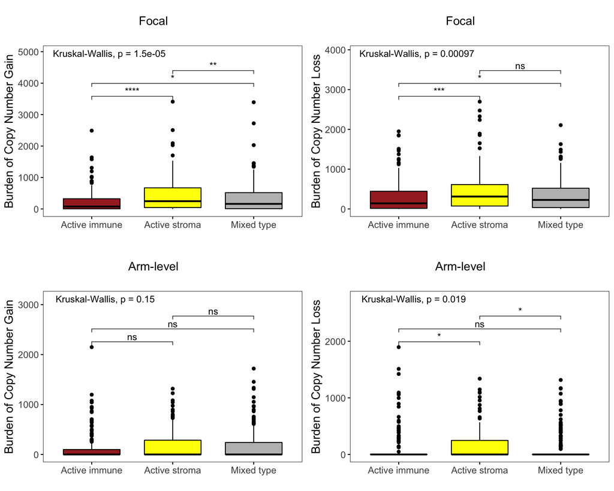

```r
# 让图中的三组数据按顺序排列
copyload$TME_Subtype <- factor(copyload$TME_Subtype, levels = c("Active immune",
                                                                "Active stroma",
                                                                "Mixed type"))
# 对比时的分组
my_comparisons <- list(c("Active immune", "Active stroma"),
                       c("Active immune", "Mixed type"),
                       c("Active stroma", "Mixed type"))

# 画图，写在list里
copyplot <- lapply(1:4, function(i){
  loadname <- colnames(copyload)[3:6]
  plotdata <- copyload[, c(loadname[i], "TME_Subtype")]
  colnames(plotdata) <- c("loadtype", "TME_Subtype")
  ylabel <- c("Burden of Copy Number Gain", "Burden of Copy Number Loss",
              "Burden of Copy Number Gain", "Burden of Copy Number Loss")
  mainlabel <- c("Focal", "Focal", "Arm-level", "Arm-level")
  label <- ggdraw() + draw_label(mainlabel[i])
  ymax <- max(plotdata$loadtype)
  plot_grid(label,
            ggpubr::ggboxplot(plotdata, x = "TME_Subtype", y = "loadtype",
                    fill = "TME_Subtype", palette =c("brown", "yellow", "grey"),
                    ggtheme = theme_bw()) +
              theme(panel.grid =element_blank()) +
              xlab("") +
              ylab(ylabel[i]) +
              theme(legend.position = "none")+
              theme(axis.title.y = element_text(size = rel(1.25)),
                    axis.text.x = element_text(size = rel(1.25)),
                    axis.text.y = element_text(size = rel(1.25))) +
              stat_compare_means(comparisons = my_comparisons, label = "p.signif") +
              stat_compare_means(label.y = 1.45*ymax,
                                 label.x = 0.8),
            ncol=1, rel_heights=c(.2, 1))
  })
# 组图
cowplot::plot_grid(plotlist = copyplot, ncol = 2)
```

```r
ggsave("CNVload.pdf", width = 10, height = 8)
```